# Assignment 3 — Time-Series Forecasting with RNNs (Jena Climate)

**Goal.** Improve on the weather time-series forecasting models from class: given the past **5 days** of hourly weather readings (14 variables), predict the **air temperature 24 hours later**. Performance is measured as **Mean Absolute Error (MAE, °C)**.

**Methods tested** (as listed in the assignment):

1. Adjusting the **number of units** in each recurrent layer of the stacked setup.
2. Using **LSTM instead of GRU** layers.
3. Using a **combination of 1D convnets and an RNN**.

Model selection is done on **validation MAE only**; the best-performing models are then evaluated **once on the test set**.

**Data / setup** follow the class material (Chollet, *Deep Learning with Python*, Ch. 10): sampling rate = 6 (one point per hour), sequence length = 120 (5 days), delay = 24 h after the end of the sequence, 50 % / 25 % / 25 % chronological train / validation / test split, inputs normalised with training-set statistics, batch size 256, RMSprop optimiser, MSE loss with MAE as the monitored metric.

## 1. Setup

```python
import os, glob, time, zipfile
import numpy as np
import pandas as pd
import matplotlib.pyplot as plt
import tensorflow as tf
import keras
from keras import layers

SEED = 42
keras.utils.set_random_seed(SEED)

print("TensorFlow:", tf.__version__, "| Keras:", keras.__version__)
print("GPUs:", tf.config.list_physical_devices("GPU"))
```

```
TensorFlow: 2.21.0 | Keras: 3.13.2
GPUs: [PhysicalDevice(name='/physical_device:GPU:0', device_type='GPU'), PhysicalDevice(name='/physical_device:GPU:1', device_type='GPU')]
```

## 2. Load the Jena climate data (2009–2016)

```python
# On Kaggle the CSV is attached as an input dataset; otherwise download the original file used in class.
cands = glob.glob("/kaggle/input/**/jena_climate_2009_2016.csv", recursive=True)
if cands:
    fname = cands[0]
else:
    zpath = keras.utils.get_file(
        "jena_climate_2009_2016.csv.zip",
        "https://s3.amazonaws.com/keras-datasets/jena_climate_2009_2016.csv.zip")
    with zipfile.ZipFile(zpath) as z:
        z.extractall(os.path.dirname(zpath))
    fname = os.path.join(os.path.dirname(zpath), "jena_climate_2009_2016.csv")

df = pd.read_csv(fname)
print(fname)
print(df.shape)
df.head()
```

```
/kaggle/input/datasets/mnassrib/jena-climate/jena_climate_2009_2016.csv
(420551, 15)
```

|  | Date Time | p (mbar) | T (degC) | Tpot (K) | Tdew (degC) | rh (%) | VPmax (mbar) | VPact (mbar) | VPdef (mbar) | sh (g/kg) | H2OC (mmol/mol) | rho (g/m**3) | wv (m/s) | max. wv (m/s) | wd (deg) |
| --- | --- | --- | --- | --- | --- | --- | --- | --- | --- | --- | --- | --- | --- | --- | --- |
| 0 | 01.01.2009 00:10:00 | 996.52 | -8.02 | 265.40 | -8.90 | 93.3 | 3.33 | 3.11 | 0.22 | 1.94 | 3.12 | 1307.75 | 1.03 | 1.75 | 152.3 |
| 1 | 01.01.2009 00:20:00 | 996.57 | -8.41 | 265.01 | -9.28 | 93.4 | 3.23 | 3.02 | 0.21 | 1.89 | 3.03 | 1309.80 | 0.72 | 1.50 | 136.1 |
| 2 | 01.01.2009 00:30:00 | 996.53 | -8.51 | 264.91 | -9.31 | 93.9 | 3.21 | 3.01 | 0.20 | 1.88 | 3.02 | 1310.24 | 0.19 | 0.63 | 171.6 |
| 3 | 01.01.2009 00:40:00 | 996.51 | -8.31 | 265.12 | -9.07 | 94.2 | 3.26 | 3.07 | 0.19 | 1.92 | 3.08 | 1309.19 | 0.34 | 0.50 | 198.0 |
| 4 | 01.01.2009 00:50:00 | 996.51 | -8.27 | 265.15 | -9.04 | 94.1 | 3.27 | 3.08 | 0.19 | 1.92 | 3.09 | 1309.00 | 0.32 | 0.63 | 214.3 |

**Data quality check.** The two wind-speed columns contain a sensor error code (-9999 m/s) in a handful of rows. Left in, these become extreme outliers after normalisation, so they are replaced with 0 m/s (calm), which is the physically plausible value. No other column contains invalid values.

```python
print("Invalid (-9999) values per column:")
print((df.iloc[:, 1:] == -9999).sum()[lambda s: s > 0])
for col in ["wv (m/s)", "max. wv (m/s)"]:
    df.loc[df[col] == -9999.0, col] = 0.0
print("Remaining -9999 values:", int((df.iloc[:, 1:] == -9999).sum().sum()))
print(df[["wv (m/s)", "max. wv (m/s)"]].describe().loc[["min", "max"]])
```

```
Invalid (-9999) values per column:
wv (m/s)         18
max. wv (m/s)    20
dtype: int64
Remaining -9999 values: 0
     wv (m/s)  max. wv (m/s)
min      0.00            0.0
max     28.49           23.5
```

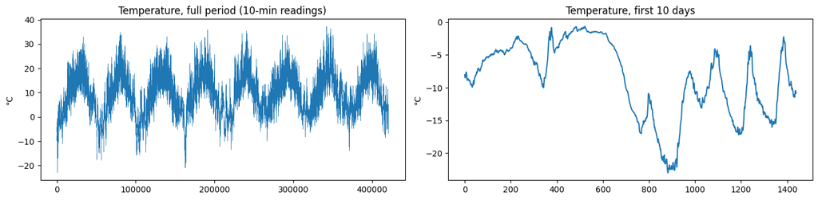

```python
# All 14 numeric columns are inputs (the date column is dropped); the target is air temperature.
raw_data = df.iloc[:, 1:].values.astype("float32")
temperature = df["T (degC)"].values.astype("float32")
TEMP_COL = list(df.columns[1:]).index("T (degC)")   # = 1

fig, ax = plt.subplots(1, 2, figsize=(14, 3.5))
ax[0].plot(temperature, lw=0.3); ax[0].set_title("Temperature, full period (10-min readings)")
ax[1].plot(temperature[:1440]);  ax[1].set_title("Temperature, first 10 days")
for a in ax: a.set_ylabel("°C")
plt.tight_layout(); plt.show()
```

## 3. Train / validation / test split and normalisation

```python
num_train_samples = int(0.5 * len(raw_data))
num_val_samples   = int(0.25 * len(raw_data))
num_test_samples  = len(raw_data) - num_train_samples - num_val_samples
print("num_train_samples:", num_train_samples)
print("num_val_samples:  ", num_val_samples)
print("num_test_samples: ", num_test_samples)

# Normalise using training statistics only (no information leaks from val/test).
mean = raw_data[:num_train_samples].mean(axis=0)
std  = raw_data[:num_train_samples].std(axis=0)
raw_data = (raw_data - mean) / std
```

```
num_train_samples: 210275
num_val_samples:   105137
num_test_samples:  105139
```

## 4. Windowed datasets

```python
sampling_rate   = 6                                   # one observation per hour
sequence_length = 120                                 # look back 5 days
delay = sampling_rate * (sequence_length + 24 - 1)    # target = temperature 24 h after the sequence ends
batch_size = 256

def make_ds(start, end, shuffle):
    return keras.utils.timeseries_dataset_from_array(
        raw_data[:-delay], targets=temperature[delay:],
        sampling_rate=sampling_rate, sequence_length=sequence_length,
        shuffle=shuffle, batch_size=batch_size,
        start_index=start, end_index=end)

train_dataset = make_ds(0, num_train_samples, True)
val_dataset   = make_ds(num_train_samples, num_train_samples + num_val_samples, True)
test_dataset  = make_ds(num_train_samples + num_val_samples, None, True)
test_ordered  = make_ds(num_train_samples + num_val_samples, None, False)   # chronological, for plotting

for samples, targets in train_dataset.take(1):
    print("samples shape:", samples.shape, "| targets shape:", targets.shape)
```

```
samples shape: (256, 120, 14) | targets shape: (256,)
```

## 5. Common-sense (no-learning) baseline

Predict that the temperature 24 h from now equals the last observed temperature. Any model must beat this.

```python
def evaluate_naive_method(dataset):
    total_abs_err, n = 0.0, 0
    for samples, targets in dataset:
        preds = samples[:, -1, TEMP_COL] * std[TEMP_COL] + mean[TEMP_COL]
        total_abs_err += float(np.sum(np.abs(preds - targets)))
        n += samples.shape[0]
    return total_abs_err / n

baseline_val  = evaluate_naive_method(val_dataset)
baseline_test = evaluate_naive_method(test_dataset)
print(f"Baseline  validation MAE: {baseline_val:.2f} °C")
print(f"Baseline  test MAE:       {baseline_test:.2f} °C")
```

```
Baseline  validation MAE: 2.44 °C
Baseline  test MAE:       2.62 °C
```

## 6. Experiment harness

Every model is trained under identical conditions so the comparison is fair: same data pipeline, same seed, RMSprop, MSE loss, up to `EPOCHS` epochs with **early stopping on validation MAE** (`patience = PATIENCE`, best weights restored), and the best checkpoint saved to disk.

```python
EPOCHS   = 40
PATIENCE = 6

results, histories, builders = {}, {}, {}
seed_runs = []   # (model name, seed, best val MAE) for the robustness check in section 12

def run_experiment(name, group, build_fn, seed=SEED, epochs=None, patience=None, plot=True):
    # Train one model under the shared protocol; returns the model with its best weights restored.
    epochs, patience = epochs or EPOCHS, patience or PATIENCE
    keras.utils.set_random_seed(seed)
    model = build_fn()
    model.compile(optimizer="rmsprop", loss="mse", metrics=["mae"])
    ckpt = f"{name} (seed {seed}).keras"
    callbacks = [
        keras.callbacks.ModelCheckpoint(ckpt, monitor="val_mae", save_best_only=True),
        keras.callbacks.EarlyStopping(monitor="val_mae", patience=patience, restore_best_weights=True),
    ]
    t0 = time.time()
    h = model.fit(train_dataset, epochs=epochs, validation_data=val_dataset,
                  callbacks=callbacks, verbose=2)
    mins = (time.time() - t0) / 60
    best_ep = int(np.argmin(h.history["val_mae"]))
    best_val = float(h.history["val_mae"][best_ep])
    seed_runs.append(dict(model=name, seed=seed, val_mae=best_val, checkpoint=ckpt))
    if seed == SEED:
        builders[name] = build_fn
        results[name] = dict(group=group, params=model.count_params(),
                             best_epoch=best_ep + 1, epochs_run=len(h.history["val_mae"]),
                             train_mae=float(h.history["mae"][best_ep]),
                             val_mae=best_val, minutes=round(mins, 1))
        histories[name] = h.history
    print(f"\n>>> {name} [seed {seed}]: best val MAE = {best_val:.3f} °C at epoch {best_ep+1} "
          f"({mins:.1f} min)\n")
    if plot:
        plot_history(f"{name} (seed {seed})", h.history)
    return model

def plot_history(name, hist):
    ep = range(1, len(hist["mae"]) + 1)
    plt.figure(figsize=(7, 3.5))
    plt.plot(ep, hist["mae"], "o-", ms=3, label="Training MAE")
    plt.plot(ep, hist["val_mae"], "s-", ms=3, label="Validation MAE")
    plt.axhline(baseline_val, color="grey", ls="--", label=f"Baseline val MAE ({baseline_val:.2f})")
    plt.title(name); plt.xlabel("Epoch"); plt.ylabel("MAE (°C)"); plt.legend(); plt.tight_layout(); plt.show()

N_FEAT = raw_data.shape[-1]
def inputs():
    return keras.Input(shape=(sequence_length, N_FEAT))
```

## 7. Reference model from class: simple LSTM(16)

The first model in class to beat the baseline. It is kept here as the reference point the experiments try to improve.

```
819/819 - 25s - 31ms/step - loss: 43.8570 - mae: 4.8251 - val_loss: 13.3707 - val_mae: 2.7606
819/819 - 24s - 29ms/step - loss: 10.9132 - mae: 2.5730 - val_loss: 9.8218 - val_mae: 2.4400
819/819 - 23s - 28ms/step - loss: 9.7225 - mae: 2.4407 - val_loss: 9.5855 - val_mae: 2.4191
819/819 - 23s - 29ms/step - loss: 9.3071 - mae: 2.3854 - val_loss: 9.5121 - val_mae: 2.3996
819/819 - 24s - 29ms/step - loss: 8.9800 - mae: 2.3421 - val_loss: 9.7185 - val_mae: 2.4275
819/819 - 23s - 29ms/step - loss: 8.6960 - mae: 2.3042 - val_loss: 9.9400 - val_mae: 2.4454
819/819 - 23s - 29ms/step - loss: 8.5078 - mae: 2.2771 - val_loss: 10.0532 - val_mae: 2.4600
819/819 - 23s - 28ms/step - loss: 8.3300 - mae: 2.2542 - val_loss: 10.0342 - val_mae: 2.4602
819/819 - 23s - 28ms/step - loss: 8.1905 - mae: 2.2346 - val_loss: 10.0532 - val_mae: 2.4633
819/819 - 23s - 28ms/step - loss: 8.0815 - mae: 2.2193 - val_loss: 10.0146 - val_mae: 2.4540

>>> Ref: LSTM(16) [seed 42]: best val MAE = 2.400 °C at epoch 4 (3.9 min)
```

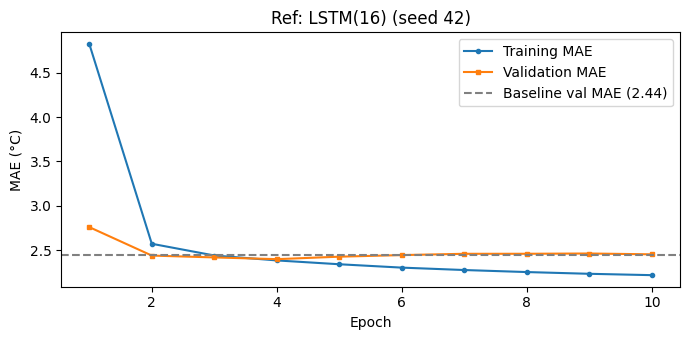

```python
def lstm16():
    i = inputs()
    x = layers.LSTM(16)(i)
    return keras.Model(i, layers.Dense(1)(x))

run_experiment("Ref: LSTM(16)", "Reference", lstm16);
```

## 8. Experiment A — number of units in the stacked GRU setup

The class's stacked model: two GRU layers with recurrent dropout, followed by dropout and a Dense output. Only the number of units per recurrent layer changes (16 → 32 → 64 → 128); everything else is fixed: `dropout = 0.2` on each recurrent layer's inputs and `Dropout(0.5)` before the output.

*Note on regularisation.* In class, `recurrent_dropout` was used. Any `recurrent_dropout > 0` disables the cuDNN GPU kernel, and in a first test run on Kaggle (T4 GPU) a single epoch of the smallest stacked GRU took more than 6 minutes, against about 25 s with cuDNN, which made a fair multi-model comparison infeasible. The experiments therefore keep the recurrent connections dropout-free and regularise with input dropout instead. Keras applies the **same input-dropout mask at every timestep** (the Gal & Ghahramani scheme from the lecture), plus dropout before the regressor and early stopping.

```python
DROPOUT, HEAD_DROPOUT = 0.2, 0.5   # input dropout per RNN layer, dropout before Dense

def stacked_rnn(cell, units1, units2):
    def build():
        i = inputs()
        x = cell(units1, dropout=DROPOUT, return_sequences=True)(i)
        x = cell(units2, dropout=DROPOUT)(x)
        x = layers.Dropout(HEAD_DROPOUT)(x)
        return keras.Model(i, layers.Dense(1)(x))
    return build
```

```
819/819 - 28s - 34ms/step - loss: 46.3994 - mae: 5.0989 - val_loss: 13.3762 - val_mae: 2.7416
819/819 - 26s - 32ms/step - loss: 20.9282 - mae: 3.5192 - val_loss: 10.1178 - val_mae: 2.4478
819/819 - 26s - 31ms/step - loss: 19.2046 - mae: 3.3754 - val_loss: 9.6704 - val_mae: 2.4096
819/819 - 26s - 31ms/step - loss: 18.0752 - mae: 3.2780 - val_loss: 9.8132 - val_mae: 2.4273
819/819 - 26s - 31ms/step - loss: 17.1670 - mae: 3.1932 - val_loss: 9.6608 - val_mae: 2.4083
819/819 - 25s - 31ms/step - loss: 16.5088 - mae: 3.1340 - val_loss: 9.6922 - val_mae: 2.4212
819/819 - 26s - 31ms/step - loss: 16.0349 - mae: 3.0877 - val_loss: 9.3501 - val_mae: 2.3715
819/819 - 26s - 31ms/step - loss: 15.5452 - mae: 3.0446 - val_loss: 9.8480 - val_mae: 2.4428
819/819 - 26s - 31ms/step - loss: 15.1881 - mae: 3.0097 - val_loss: 9.1205 - val_mae: 2.3418
819/819 - 25s - 31ms/step - loss: 14.8859 - mae: 2.9795 - val_loss: 10.0532 - val_mae: 2.4561
819/819 - 25s - 31ms/step - loss: 14.7461 - mae: 2.9658 - val_loss: 9.0754 - val_mae: 2.3403
819/819 - 25s - 30ms/step - loss: 14.5573 - mae: 2.9476 - val_loss: 9.0615 - val_mae: 2.3383
819/819 - 25s - 30ms/step - loss: 14.3076 - mae: 2.9221 - val_loss: 10.0701 - val_mae: 2.4750
819/819 - 25s - 31ms/step - loss: 14.1862 - mae: 2.9124 - val_loss: 10.1606 - val_mae: 2.4921
819/819 - 25s - 31ms/step - loss: 14.0200 - mae: 2.8931 - val_loss: 9.8056 - val_mae: 2.4403
819/819 - 25s - 31ms/step - loss: 13.9215 - mae: 2.8788 - val_loss: 9.7942 - val_mae: 2.4442
819/819 - 25s - 30ms/step - loss: 13.8287 - mae: 2.8731 - val_loss: 9.2687 - val_mae: 2.3664
819/819 - 25s - 30ms/step - loss: 13.6946 - mae: 2.8632 - val_loss: 10.2828 - val_mae: 2.5207

>>> A1: Stacked GRU 16-16 [seed 42]: best val MAE = 2.338 °C at epoch 12 (7.6 min)
```

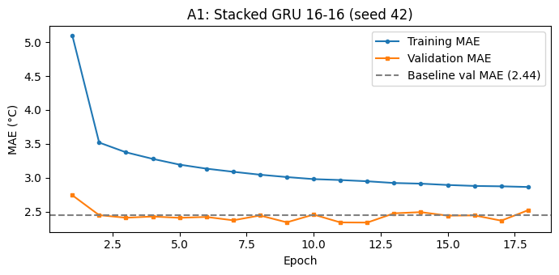

```python
run_experiment("A1: Stacked GRU 16-16", "A: units (GRU)", stacked_rnn(layers.GRU, 16, 16));
```

```
819/819 - 27s - 33ms/step - loss: 27.8160 - mae: 3.9327 - val_loss: 9.9707 - val_mae: 2.4405
819/819 - 25s - 31ms/step - loss: 15.6593 - mae: 3.0731 - val_loss: 9.3901 - val_mae: 2.3730
819/819 - 25s - 31ms/step - loss: 14.6976 - mae: 2.9753 - val_loss: 9.2262 - val_mae: 2.3575
819/819 - 25s - 30ms/step - loss: 13.9620 - mae: 2.8977 - val_loss: 9.5463 - val_mae: 2.3959
819/819 - 25s - 31ms/step - loss: 13.5037 - mae: 2.8530 - val_loss: 9.1635 - val_mae: 2.3528
819/819 - 25s - 31ms/step - loss: 13.0359 - mae: 2.8051 - val_loss: 9.2341 - val_mae: 2.3593
819/819 - 25s - 31ms/step - loss: 12.7219 - mae: 2.7722 - val_loss: 9.7091 - val_mae: 2.4267
819/819 - 26s - 32ms/step - loss: 12.4154 - mae: 2.7395 - val_loss: 10.0904 - val_mae: 2.4672
819/819 - 25s - 31ms/step - loss: 12.1585 - mae: 2.7129 - val_loss: 9.0045 - val_mae: 2.3320
819/819 - 25s - 31ms/step - loss: 11.8633 - mae: 2.6791 - val_loss: 9.8313 - val_mae: 2.4402
819/819 - 25s - 30ms/step - loss: 11.6004 - mae: 2.6526 - val_loss: 10.0005 - val_mae: 2.4762
819/819 - 25s - 30ms/step - loss: 11.3839 - mae: 2.6301 - val_loss: 9.0737 - val_mae: 2.3514
819/819 - 24s - 30ms/step - loss: 11.2035 - mae: 2.6037 - val_loss: 10.1828 - val_mae: 2.4993
819/819 - 25s - 30ms/step - loss: 10.9686 - mae: 2.5794 - val_loss: 10.0184 - val_mae: 2.4794
819/819 - 25s - 30ms/step - loss: 10.8607 - mae: 2.5662 - val_loss: 10.0787 - val_mae: 2.4676

>>> A2: Stacked GRU 32-32 [seed 42]: best val MAE = 2.332 °C at epoch 9 (6.3 min)
```

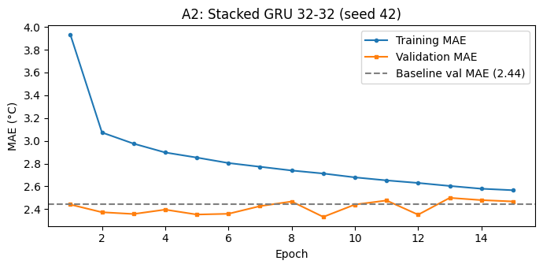

```python
run_experiment("A2: Stacked GRU 32-32", "A: units (GRU)", stacked_rnn(layers.GRU, 32, 32));
```

```
819/819 - 27s - 33ms/step - loss: 18.1421 - mae: 3.2313 - val_loss: 9.5579 - val_mae: 2.4071
819/819 - 25s - 31ms/step - loss: 12.7038 - mae: 2.7817 - val_loss: 9.4980 - val_mae: 2.4029
819/819 - 25s - 30ms/step - loss: 11.7707 - mae: 2.6796 - val_loss: 9.8208 - val_mae: 2.4366
819/819 - 25s - 30ms/step - loss: 11.0760 - mae: 2.5976 - val_loss: 9.5133 - val_mae: 2.4234
819/819 - 25s - 31ms/step - loss: 10.5978 - mae: 2.5416 - val_loss: 9.8803 - val_mae: 2.4630
819/819 - 25s - 31ms/step - loss: 10.0717 - mae: 2.4768 - val_loss: 10.3548 - val_mae: 2.5254
819/819 - 25s - 31ms/step - loss: 9.5471 - mae: 2.4071 - val_loss: 9.8465 - val_mae: 2.4578
819/819 - 25s - 31ms/step - loss: 9.0383 - mae: 2.3426 - val_loss: 10.1895 - val_mae: 2.4999

>>> A3: Stacked GRU 64-64 [seed 42]: best val MAE = 2.403 °C at epoch 2 (3.4 min)
```

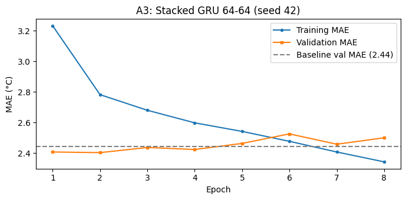

```python
run_experiment("A3: Stacked GRU 64-64", "A: units (GRU)", stacked_rnn(layers.GRU, 64, 64));
```

```
819/819 - 29s - 35ms/step - loss: 14.2289 - mae: 2.9111 - val_loss: 9.4093 - val_mae: 2.3827
819/819 - 28s - 34ms/step - loss: 10.7994 - mae: 2.5746 - val_loss: 9.9532 - val_mae: 2.4536
819/819 - 27s - 33ms/step - loss: 9.6265 - mae: 2.4276 - val_loss: 10.5229 - val_mae: 2.5218
819/819 - 28s - 34ms/step - loss: 8.4233 - mae: 2.2657 - val_loss: 10.8071 - val_mae: 2.5564
819/819 - 27s - 33ms/step - loss: 7.3446 - mae: 2.1112 - val_loss: 11.1512 - val_mae: 2.5958
819/819 - 27s - 33ms/step - loss: 6.4599 - mae: 1.9729 - val_loss: 12.6144 - val_mae: 2.7871
819/819 - 27s - 33ms/step - loss: 5.7605 - mae: 1.8593 - val_loss: 11.8965 - val_mae: 2.6754

>>> A4: Stacked GRU 128-128 [seed 42]: best val MAE = 2.383 °C at epoch 1 (3.2 min)
```

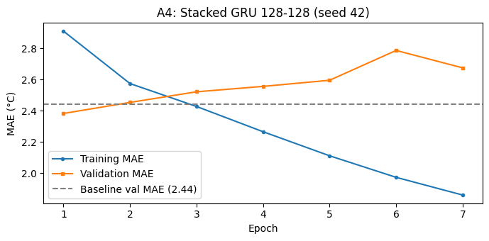

```python
run_experiment("A4: Stacked GRU 128-128", "A: units (GRU)", stacked_rnn(layers.GRU, 128, 128));
```

## 9. Experiment B — LSTM instead of GRU

Same stacked architecture and regularisation as Experiment A, with LSTM layers replacing GRU layers, at two widths so it can be compared one-for-one with A2 and A3.

```
819/819 - 27s - 32ms/step - loss: 27.7120 - mae: 3.9269 - val_loss: 10.4039 - val_mae: 2.5118
819/819 - 25s - 31ms/step - loss: 15.6669 - mae: 3.0779 - val_loss: 9.3464 - val_mae: 2.3800
819/819 - 25s - 31ms/step - loss: 14.4275 - mae: 2.9530 - val_loss: 10.0824 - val_mae: 2.4789
819/819 - 25s - 31ms/step - loss: 13.7091 - mae: 2.8719 - val_loss: 9.4578 - val_mae: 2.3907
819/819 - 25s - 31ms/step - loss: 13.1974 - mae: 2.8157 - val_loss: 10.2649 - val_mae: 2.5000
819/819 - 25s - 30ms/step - loss: 12.6526 - mae: 2.7571 - val_loss: 9.2655 - val_mae: 2.3640
819/819 - 25s - 30ms/step - loss: 12.2568 - mae: 2.7159 - val_loss: 9.8352 - val_mae: 2.4593
819/819 - 25s - 31ms/step - loss: 11.8433 - mae: 2.6695 - val_loss: 9.8916 - val_mae: 2.4542
819/819 - 25s - 31ms/step - loss: 11.6495 - mae: 2.6444 - val_loss: 9.3441 - val_mae: 2.3831
819/819 - 25s - 31ms/step - loss: 11.2861 - mae: 2.6053 - val_loss: 9.2956 - val_mae: 2.3792
819/819 - 25s - 31ms/step - loss: 11.1019 - mae: 2.5827 - val_loss: 9.7640 - val_mae: 2.4354
819/819 - 26s - 32ms/step - loss: 10.8042 - mae: 2.5492 - val_loss: 9.4872 - val_mae: 2.4106

>>> B1: Stacked LSTM 32-32 [seed 42]: best val MAE = 2.364 °C at epoch 6 (5.1 min)
```

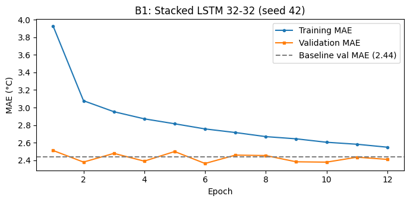

```python
run_experiment("B1: Stacked LSTM 32-32", "B: LSTM vs GRU", stacked_rnn(layers.LSTM, 32, 32));
```

```
819/819 - 28s - 34ms/step - loss: 18.1770 - mae: 3.2352 - val_loss: 9.5263 - val_mae: 2.4062
819/819 - 26s - 32ms/step - loss: 12.2994 - mae: 2.7425 - val_loss: 10.4502 - val_mae: 2.5354
819/819 - 26s - 32ms/step - loss: 11.3310 - mae: 2.6286 - val_loss: 9.4416 - val_mae: 2.4023
819/819 - 25s - 31ms/step - loss: 10.5111 - mae: 2.5259 - val_loss: 10.1173 - val_mae: 2.4920
819/819 - 25s - 30ms/step - loss: 9.8833 - mae: 2.4475 - val_loss: 10.4635 - val_mae: 2.5307
819/819 - 25s - 30ms/step - loss: 9.2338 - mae: 2.3589 - val_loss: 10.3366 - val_mae: 2.4974
819/819 - 25s - 31ms/step - loss: 8.7267 - mae: 2.2918 - val_loss: 10.5886 - val_mae: 2.5454
819/819 - 26s - 32ms/step - loss: 8.2411 - mae: 2.2222 - val_loss: 11.2485 - val_mae: 2.6415
819/819 - 26s - 31ms/step - loss: 7.8332 - mae: 2.1614 - val_loss: 11.2744 - val_mae: 2.6230

>>> B2: Stacked LSTM 64-64 [seed 42]: best val MAE = 2.402 °C at epoch 3 (3.9 min)
```

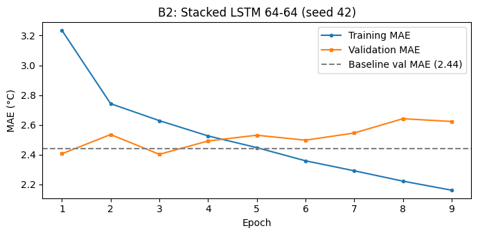

```python
run_experiment("B2: Stacked LSTM 64-64", "B: LSTM vs GRU", stacked_rnn(layers.LSTM, 64, 64));
```

## 10. Experiment C — 1D convnet + RNN

A Conv1D front end extracts local (within-day) patterns and the max-pooling step shortens the sequence (120 → 60 hourly steps); the recurrent layer then models the order of those features over the 5 days. In class a Conv1D-only model did poorly because pooling destroyed order information; here the RNN keeps it.

```python
def conv_rnn(cell, filters=32, units=32):
    def build():
        i = inputs()
        x = layers.Conv1D(filters, 12, activation="relu", padding="same")(i)   # 12-hour windows
        x = layers.MaxPooling1D(2)(x)
        x = layers.Conv1D(filters, 6, activation="relu", padding="same")(x)    # 6 pooled steps = 12 h
        x = cell(units, dropout=DROPOUT)(x)
        x = layers.Dropout(HEAD_DROPOUT)(x)
        return keras.Model(i, layers.Dense(1)(x))
    return build
```

```
819/819 - 28s - 34ms/step - loss: 23.3873 - mae: 3.5719 - val_loss: 10.1072 - val_mae: 2.4651
819/819 - 24s - 29ms/step - loss: 13.3934 - mae: 2.8310 - val_loss: 9.3133 - val_mae: 2.3628
819/819 - 24s - 29ms/step - loss: 12.3219 - mae: 2.7073 - val_loss: 9.8343 - val_mae: 2.4502
819/819 - 23s - 28ms/step - loss: 11.6114 - mae: 2.6188 - val_loss: 10.2903 - val_mae: 2.5273
819/819 - 23s - 28ms/step - loss: 10.8735 - mae: 2.5316 - val_loss: 11.7408 - val_mae: 2.6986
819/819 - 23s - 29ms/step - loss: 10.3375 - mae: 2.4723 - val_loss: 10.3256 - val_mae: 2.5213
819/819 - 23s - 29ms/step - loss: 9.9032 - mae: 2.4126 - val_loss: 11.3823 - val_mae: 2.6583
819/819 - 23s - 29ms/step - loss: 9.5340 - mae: 2.3650 - val_loss: 11.4876 - val_mae: 2.6646

>>> C1: Conv1D + GRU 32 [seed 42]: best val MAE = 2.363 °C at epoch 2 (3.2 min)
```

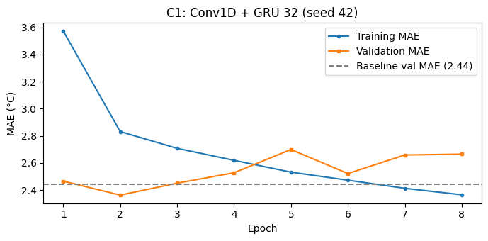

```python
run_experiment("C1: Conv1D + GRU 32", "C: Conv1D + RNN", conv_rnn(layers.GRU));
```

```
819/819 - 25s - 30ms/step - loss: 24.8013 - mae: 3.6769 - val_loss: 9.7542 - val_mae: 2.4143
819/819 - 23s - 28ms/step - loss: 13.7329 - mae: 2.8625 - val_loss: 10.5537 - val_mae: 2.5369
819/819 - 23s - 28ms/step - loss: 12.6690 - mae: 2.7403 - val_loss: 9.4053 - val_mae: 2.3756
819/819 - 24s - 29ms/step - loss: 11.7823 - mae: 2.6371 - val_loss: 10.9904 - val_mae: 2.6011
819/819 - 24s - 30ms/step - loss: 10.8951 - mae: 2.5383 - val_loss: 10.1070 - val_mae: 2.4695
819/819 - 24s - 29ms/step - loss: 10.3751 - mae: 2.4712 - val_loss: 10.6091 - val_mae: 2.5133
819/819 - 23s - 28ms/step - loss: 9.8064 - mae: 2.4005 - val_loss: 10.2823 - val_mae: 2.4857
819/819 - 23s - 28ms/step - loss: 9.3893 - mae: 2.3426 - val_loss: 11.1424 - val_mae: 2.5762
819/819 - 23s - 28ms/step - loss: 9.0051 - mae: 2.2988 - val_loss: 11.4007 - val_mae: 2.6126

>>> C2: Conv1D + LSTM 32 [seed 42]: best val MAE = 2.376 °C at epoch 3 (3.5 min)
```

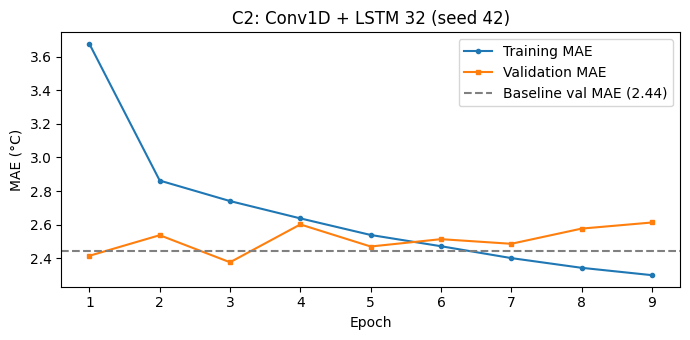

```python
run_experiment("C2: Conv1D + LSTM 32", "C: Conv1D + RNN", conv_rnn(layers.LSTM));
```

## 11. Experiment D — regularisation follow-ups (methods from the "Advanced uses" lecture)

- **D1 — Stacked GRU 64-64 with stronger dropout** (input dropout 0.4 instead of 0.2). Does the extra capacity pay off once it is regularised properly?
- **Recurrent dropout (the lecture's technique).** A stacked GRU 32-32 with `recurrent_dropout = 0.25` was run in a previous version of this notebook (Kaggle version 3). It disables the cuDNN kernel: each epoch took about **10 minutes** (vs ~25 s), and after 2 epochs it had reached a validation MAE of **2.359 °C** (epoch 1: 2.424). It could not be trained to convergence within the time available, so it is reported here only as a partial result and is not part of the comparison.

```
819/819 - 26s - 32ms/step - loss: 20.3120 - mae: 3.4424 - val_loss: 10.0696 - val_mae: 2.4731
819/819 - 25s - 30ms/step - loss: 14.1643 - mae: 2.9402 - val_loss: 11.1188 - val_mae: 2.6060
819/819 - 25s - 30ms/step - loss: 13.1584 - mae: 2.8388 - val_loss: 13.3471 - val_mae: 2.8865
819/819 - 25s - 31ms/step - loss: 12.5957 - mae: 2.7764 - val_loss: 12.0319 - val_mae: 2.7326
819/819 - 25s - 31ms/step - loss: 12.1802 - mae: 2.7256 - val_loss: 12.7464 - val_mae: 2.8173
819/819 - 25s - 30ms/step - loss: 11.7380 - mae: 2.6736 - val_loss: 12.8018 - val_mae: 2.8225
819/819 - 25s - 31ms/step - loss: 11.4372 - mae: 2.6405 - val_loss: 11.5732 - val_mae: 2.6673

>>> D1: Stacked GRU 64-64, dropout 0.4 [seed 42]: best val MAE = 2.473 °C at epoch 1 (2.9 min)
```

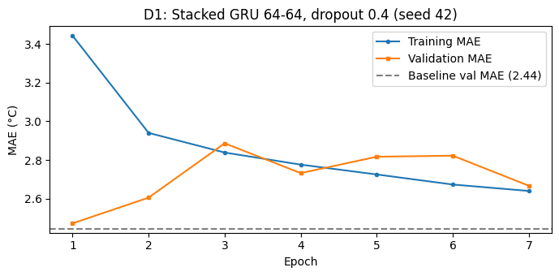

```python
def stacked_gru_custom(units, in_dropout, rec_dropout=0.0):
    def build():
        i = inputs()
        x = layers.GRU(units, dropout=in_dropout, recurrent_dropout=rec_dropout, return_sequences=True)(i)
        x = layers.GRU(units, dropout=in_dropout, recurrent_dropout=rec_dropout)(x)
        x = layers.Dropout(HEAD_DROPOUT)(x)
        return keras.Model(i, layers.Dense(1)(x))
    return build

run_experiment("D1: Stacked GRU 64-64, dropout 0.4", "D: regularisation", stacked_gru_custom(64, 0.4));
```

## 12. Validation results and robustness check

Models are ranked by validation MAE; the test set has still not been used. Because the top models are separated by only a few thousandths of a degree, the **three best models are re-trained with an additional random seed** (seed 1). The final ranking uses the **mean validation MAE over both seeds**, so the choice does not depend on one lucky initialisation.

```python
res = pd.DataFrame(results).T
res["val_mae"] = res["val_mae"].astype(float)
baseline_val = float(baseline_val)
res["improvement_vs_baseline_%"] = (100 * (baseline_val - res["val_mae"]) / baseline_val).round(1)
res = res.sort_values("val_mae")
pd.set_option("display.precision", 3)
res
```

|  | group | params | best_epoch | epochs_run | train_mae | val_mae | minutes | improvement_vs_baseline_% |
| --- | --- | --- | --- | --- | --- | --- | --- | --- |
| A2: Stacked GRU 32-32 | A: units (GRU) | 10977 | 9 | 15 | 2.713 | 2.332 | 6.3 | 4.5 |
| A1: Stacked GRU 16-16 | A: units (GRU) | 3185 | 12 | 18 | 2.948 | 2.338 | 7.6 | 4.3 |
| C1: Conv1D + GRU 32 | C: Conv1D + RNN | 17953 | 2 | 8 | 2.831 | 2.363 | 3.2 | 3.3 |
| B1: Stacked LSTM 32-32 | B: LSTM vs GRU | 14369 | 6 | 12 | 2.757 | 2.364 | 5.1 | 3.2 |
| C2: Conv1D + LSTM 32 | C: Conv1D + RNN | 19937 | 3 | 9 | 2.74 | 2.376 | 3.5 | 2.7 |
| A4: Stacked GRU 128-128 | A: units (GRU) | 154497 | 1 | 7 | 2.911 | 2.383 | 3.2 | 2.5 |
| Ref: LSTM(16) | Reference | 2001 | 4 | 10 | 2.385 | 2.400 | 3.9 | 1.8 |
| B2: Stacked LSTM 64-64 | B: LSTM vs GRU | 53313 | 3 | 9 | 2.629 | 2.402 | 3.9 | 1.7 |
| A3: Stacked GRU 64-64 | A: units (GRU) | 40385 | 2 | 8 | 2.782 | 2.403 | 3.4 | 1.6 |
| D1: Stacked GRU 64-64, dropout 0.4 | D: regularisation | 40385 | 1 | 7 | 3.442 | 2.473 | 2.9 | -1.2 |

```python
TOP_K = 3
EXTRA_SEEDS = [1]
top_single = list(res.index[:TOP_K])
print("Top models on a single seed:", top_single)

for name in top_single:
    if "recurrent dropout" in name:
        print(f"Skipping extra seeds for {name}: one run takes ~{results[name]['minutes']:.0f} min.")
        continue
    for sd in EXTRA_SEEDS:
        run_experiment(name, results[name]["group"], builders[name], seed=sd, plot=False)

seeds_df = pd.DataFrame(seed_runs)
robust = (seeds_df[seeds_df.model.isin(top_single)]
          .groupby("model")["val_mae"].agg(["mean", "std", "min", "max", "count"])
          .sort_values("mean"))
robust.columns = ["val_mae_mean", "val_mae_std", "val_mae_min", "val_mae_max", "n_seeds"]
robust
```

```
Top models on a single seed: ['A2: Stacked GRU 32-32', 'A1: Stacked GRU 16-16', 'C1: Conv1D + GRU 32']
819/819 - 26s - 32ms/step - loss: 27.2258 - mae: 3.9001 - val_loss: 9.6869 - val_mae: 2.4006
819/819 - 25s - 30ms/step - loss: 15.7091 - mae: 3.0772 - val_loss: 9.1491 - val_mae: 2.3406
819/819 - 25s - 30ms/step - loss: 14.6346 - mae: 2.9677 - val_loss: 9.1287 - val_mae: 2.3342
819/819 - 25s - 31ms/step - loss: 13.9141 - mae: 2.8969 - val_loss: 9.7020 - val_mae: 2.4120
819/819 - 25s - 31ms/step - loss: 13.4245 - mae: 2.8444 - val_loss: 9.9821 - val_mae: 2.4600
819/819 - 26s - 32ms/step - loss: 12.9585 - mae: 2.7948 - val_loss: 9.4573 - val_mae: 2.4005
819/819 - 26s - 32ms/step - loss: 12.6463 - mae: 2.7597 - val_loss: 9.4404 - val_mae: 2.3922
819/819 - 26s - 31ms/step - loss: 12.2835 - mae: 2.7259 - val_loss: 9.0768 - val_mae: 2.3518
819/819 - 25s - 30ms/step - loss: 12.0701 - mae: 2.7013 - val_loss: 9.5192 - val_mae: 2.3996

>>> A2: Stacked GRU 32-32 [seed 1]: best val MAE = 2.334 °C at epoch 3 (3.8 min)

819/819 - 26s - 32ms/step - loss: 48.9895 - mae: 5.2452 - val_loss: 14.0362 - val_mae: 2.7876
819/819 - 25s - 30ms/step - loss: 21.0222 - mae: 3.5246 - val_loss: 10.1620 - val_mae: 2.4414
819/819 - 24s - 30ms/step - loss: 19.0592 - mae: 3.3650 - val_loss: 10.0114 - val_mae: 2.4517
819/819 - 24s - 30ms/step - loss: 18.0297 - mae: 3.2693 - val_loss: 9.2136 - val_mae: 2.3548
819/819 - 24s - 30ms/step - loss: 17.1161 - mae: 3.1911 - val_loss: 9.9326 - val_mae: 2.4542
819/819 - 25s - 30ms/step - loss: 16.4361 - mae: 3.1268 - val_loss: 10.0947 - val_mae: 2.4748
819/819 - 25s - 30ms/step - loss: 15.9686 - mae: 3.0822 - val_loss: 9.7975 - val_mae: 2.4227
819/819 - 25s - 30ms/step - loss: 15.5450 - mae: 3.0448 - val_loss: 9.8632 - val_mae: 2.4488
819/819 - 24s - 30ms/step - loss: 15.2484 - mae: 3.0148 - val_loss: 9.3032 - val_mae: 2.3679
819/819 - 25s - 30ms/step - loss: 15.0367 - mae: 2.9904 - val_loss: 9.0103 - val_mae: 2.3329
819/819 - 25s - 31ms/step - loss: 14.6846 - mae: 2.9597 - val_loss: 9.5944 - val_mae: 2.4170
819/819 - 25s - 30ms/step - loss: 14.6537 - mae: 2.9600 - val_loss: 9.2682 - val_mae: 2.3680
819/819 - 25s - 30ms/step - loss: 14.3293 - mae: 2.9250 - val_loss: 9.7413 - val_mae: 2.4384
819/819 - 25s - 31ms/step - loss: 14.2566 - mae: 2.9189 - val_loss: 9.6746 - val_mae: 2.4151
819/819 - 26s - 31ms/step - loss: 14.2036 - mae: 2.9119 - val_loss: 9.7477 - val_mae: 2.4394
819/819 - 26s - 31ms/step - loss: 14.0495 - mae: 2.8932 - val_loss: 10.1111 - val_mae: 2.4921

>>> A1: Stacked GRU 16-16 [seed 1]: best val MAE = 2.333 °C at epoch 10 (6.6 min)

819/819 - 26s - 31ms/step - loss: 24.8809 - mae: 3.6603 - val_loss: 9.5016 - val_mae: 2.3720
819/819 - 23s - 29ms/step - loss: 13.4229 - mae: 2.8330 - val_loss: 10.1814 - val_mae: 2.4867
819/819 - 24s - 29ms/step - loss: 12.3355 - mae: 2.7052 - val_loss: 10.4065 - val_mae: 2.5066
819/819 - 23s - 29ms/step - loss: 11.6091 - mae: 2.6212 - val_loss: 10.2972 - val_mae: 2.4983
819/819 - 23s - 29ms/step - loss: 11.0087 - mae: 2.5491 - val_loss: 9.8928 - val_mae: 2.4443
819/819 - 23s - 28ms/step - loss: 10.4666 - mae: 2.4848 - val_loss: 10.9252 - val_mae: 2.5668
819/819 - 24s - 29ms/step - loss: 9.9878 - mae: 2.4252 - val_loss: 10.4546 - val_mae: 2.5160

>>> C1: Conv1D + GRU 32 [seed 1]: best val MAE = 2.372 °C at epoch 1 (2.8 min)
```

| model | val_mae_mean | val_mae_std | val_mae_min | val_mae_max | n_seeds |
| --- | --- | --- | --- | --- | --- |
| A2: Stacked GRU 32-32 | 2.333 | 0.002 | 2.332 | 2.334 | 2 |
| A1: Stacked GRU 16-16 | 2.336 | 0.004 | 2.333 | 2.338 | 2 |
| C1: Conv1D + GRU 32 | 2.367 | 0.007 | 2.363 | 2.372 | 2 |

```python
final_ranking = list(robust.index)
best_model = final_ranking[0]
print("Final ranking by mean validation MAE:", final_ranking)
print("Selected model:", best_model)
```

```
Final ranking by mean validation MAE: ['A2: Stacked GRU 32-32', 'A1: Stacked GRU 16-16', 'C1: Conv1D + GRU 32']
Selected model: A2: Stacked GRU 32-32
```

## 13. Test-set evaluation of the best-performing models

Each of the three selected models is evaluated on the held-out test set **once per trained seed** (the saved best-validation checkpoint), and the mean ± standard deviation is reported.

```python
test_rows = []
for name in final_ranking:
    runs = seeds_df[seeds_df.model == name]
    maes = []
    for _, r in runs.iterrows():
        m = keras.models.load_model(r["checkpoint"])
        maes.append(m.evaluate(test_dataset, verbose=0)[1])
    test_rows.append(dict(model=name, n_seeds=len(maes),
                          val_mae_mean=robust.loc[name, "val_mae_mean"],
                          test_mae_mean=np.mean(maes), test_mae_std=np.std(maes, ddof=1) if len(maes) > 1 else 0.0,
                          test_mae_best_seed=min(maes)))
test_res = pd.DataFrame(test_rows).set_index("model")
test_res["test_improvement_vs_baseline_%"] = 100 * (baseline_test - test_res["test_mae_mean"]) / baseline_test
test_res.loc["Common-sense baseline"] = [np.nan, baseline_val, baseline_test, 0.0, baseline_test, 0.0]
test_res
```

| model | n_seeds | val_mae_mean | test_mae_mean | test_mae_std | test_mae_best_seed | test_improvement_vs_baseline_% |
| --- | --- | --- | --- | --- | --- | --- |
| A2: Stacked GRU 32-32 | 2.0 | 2.333 | 2.535 | 0.035 | 2.510 | 3.278 |
| A1: Stacked GRU 16-16 | 2.0 | 2.336 | 2.528 | 0.030 | 2.507 | 3.538 |
| C1: Conv1D + GRU 32 | 2.0 | 2.367 | 2.590 | 0.049 | 2.555 | 1.192 |
| Common-sense baseline | NaN | 2.443 | 2.621 | 0.000 | 2.621 | 0.000 |

## 14. Summary graphs

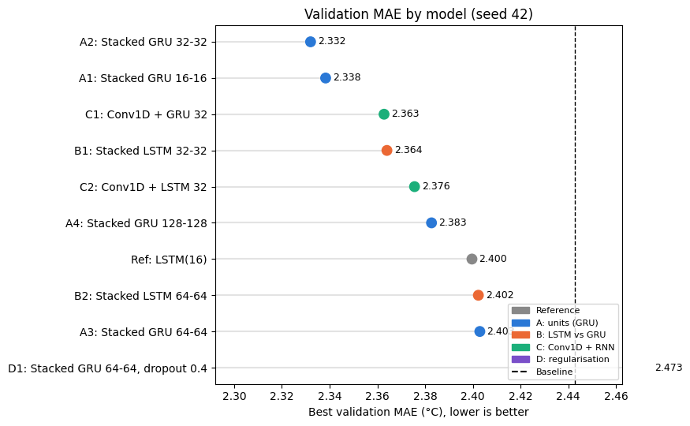

```python
colors = {"Reference": "#888888", "A: units (GRU)": "#2a78d6", "B: LSTM vs GRU": "#eb6834",
          "C: Conv1D + RNN": "#1baf7a", "D: regularisation": "#7a4fc9"}
plot_df = res.sort_values("val_mae", ascending=False)
fig, ax = plt.subplots(figsize=(9, 5.5))
ax.hlines(range(len(plot_df)), 2.2, plot_df["val_mae"], color="#e3e3e3")
ax.scatter(plot_df["val_mae"], range(len(plot_df)), s=80, zorder=3,
           color=[colors[g] for g in plot_df["group"]])
for y, v in enumerate(plot_df["val_mae"]):
    ax.text(v + 0.003, y, f"{v:.3f}", va="center", fontsize=9)
ax.set_yticks(range(len(plot_df))); ax.set_yticklabels(plot_df.index)
ax.axvline(baseline_val, color="black", ls="--", lw=1)
ax.set_xlim(plot_df["val_mae"].min() - 0.04, baseline_val + 0.02)
ax.set_xlabel("Best validation MAE (°C), lower is better"); ax.set_title("Validation MAE by model (seed 42)")
from matplotlib.patches import Patch
ax.legend(handles=[Patch(color=c, label=g) for g, c in colors.items()] +
          [plt.Line2D([], [], color="black", ls="--", label="Baseline")], loc="lower right", fontsize=8)
plt.tight_layout(); plt.savefig("val_mae_by_model.png", dpi=150); plt.show()
```

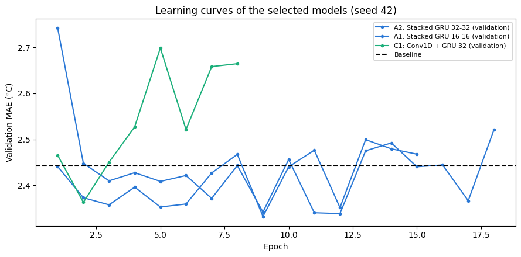

```python
plt.figure(figsize=(9, 4.5))
for name in final_ranking:
    h = histories[name]
    plt.plot(range(1, len(h["val_mae"]) + 1), h["val_mae"], "o-", ms=3, label=f"{name} (validation)",
             color=colors[results[name]["group"]])
plt.axhline(baseline_val, color="black", ls="--", label="Baseline")
plt.xlabel("Epoch"); plt.ylabel("Validation MAE (°C)"); plt.title("Learning curves of the selected models (seed 42)")
plt.legend(fontsize=8); plt.tight_layout(); plt.savefig("val_curves.png", dpi=150); plt.show()
```

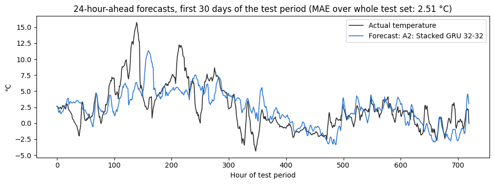

```python
# Forecast vs actual on the first 30 days of the test period (chronological windows, selected model, seed 42).
m = keras.models.load_model(f"{best_model} (seed {SEED}).keras")
preds, actual = [], []
for xb, yb in test_ordered:
    preds.append(m.predict(xb, verbose=0).ravel()); actual.append(yb.numpy())
preds, actual = np.concatenate(preds), np.concatenate(actual)
# Windows start every 10 minutes; keep one forecast per hour, then plot the first 30 days (720 hours).
preds_h, actual_h = preds[::6], actual[::6]
n = 30 * 24
plt.figure(figsize=(10, 3.8))
plt.plot(actual_h[:n], label="Actual temperature", lw=1.2, color="#2b2b2b")
plt.plot(preds_h[:n], label=f"Forecast: {best_model}", lw=1.2, color="#2a78d6")
plt.xlabel("Hour of test period"); plt.ylabel("°C"); plt.legend()
plt.title(f"24-hour-ahead forecasts, first 30 days of the test period (MAE over whole test set: {np.mean(np.abs(preds-actual)):.2f} °C)")
plt.tight_layout(); plt.savefig("forecast_vs_actual.png", dpi=150); plt.show()
```

```python
# Save all numbers so the written summary uses exactly these values.
import json
res.to_csv("validation_results.csv")
robust.to_csv("seed_robustness.csv")
seeds_df.to_csv("seed_runs.csv", index=False)
test_res.to_csv("test_results.csv")
pd.DataFrame({"actual": actual_h, "forecast": preds_h}).to_csv("test_forecasts_best_model_hourly.csv", index=False)
with open("histories.json", "w") as f:
    json.dump({k: {m: [float(v) for v in vals] for m, vals in h.items()} for k, h in histories.items()}, f)
print(res[["group", "params", "best_epoch", "val_mae", "improvement_vs_baseline_%"]].to_string())
print(); print(robust.to_string()); print(); print(test_res.to_string())
```

```
                                                group  params best_epoch  val_mae  improvement_vs_baseline_%
A2: Stacked GRU 32-32                  A: units (GRU)   10977          9    2.332                        4.5
A1: Stacked GRU 16-16                  A: units (GRU)    3185         12    2.338                        4.3
C1: Conv1D + GRU 32                   C: Conv1D + RNN   17953          2    2.363                        3.3
B1: Stacked LSTM 32-32                 B: LSTM vs GRU   14369          6    2.364                        3.2
C2: Conv1D + LSTM 32                  C: Conv1D + RNN   19937          3    2.376                        2.7
A4: Stacked GRU 128-128                A: units (GRU)  154497          1    2.383                        2.5
Ref: LSTM(16)                               Reference    2001          4    2.400                        1.8
B2: Stacked LSTM 64-64                 B: LSTM vs GRU   53313          3    2.402                        1.7
A3: Stacked GRU 64-64                  A: units (GRU)   40385          2    2.403                        1.6
D1: Stacked GRU 64-64, dropout 0.4  D: regularisation   40385          1    2.473                       -1.2

                       val_mae_mean  val_mae_std  val_mae_min  val_mae_max  n_seeds
model
A2: Stacked GRU 32-32         2.333        0.002        2.332        2.334        2
A1: Stacked GRU 16-16         2.336        0.004        2.333        2.338        2
C1: Conv1D + GRU 32           2.367        0.007        2.363        2.372        2

                       n_seeds  val_mae_mean  test_mae_mean  test_mae_std  test_mae_best_seed  test_improvement_vs_baseline_%
model
A2: Stacked GRU 32-32      2.0         2.333          2.535         0.035               2.510                           3.278
A1: Stacked GRU 16-16      2.0         2.336          2.528         0.030               2.507                           3.538
C1: Conv1D + GRU 32        2.0         2.367          2.590         0.049               2.555                           1.192
Common-sense baseline      NaN         2.443          2.621         0.000               2.621                           0.000
```